# Final Take Home

Broderick Prows

4/16/2020

Set up Functions for Gibbs Sampling

```r
set.seed(101)
library(invgamma)
library(MASS)

update_mu <- function(sigma2, m, v, n, y_bar) {
  # update m
  m_star <- ((n*v*y_bar) + (sigma2*m)) / (n*v + sigma2)
  # update v
  v_star <- (v*sigma2) / (n*v + sigma2)

  next_mu <- rnorm(1, mean = m_star, sd = sqrt(v_star))

  return(next_mu)
}

update_sig2 <- function(a, b, n, Y, mu) {
  # update a
  a_star <- a + (n/2)
  #update b
  b_star <- b + (sum((Y-mu)**2)/2)

  next_sig2 <- rinvgamma(1,shape = a_star, rate = b_star)

  return(next_sig2)
}

gibbs_normal_invGamma <- function(m,v, a,b, Y, J = 10000) {
  # Define n, y_bar for data given
  n <- length(Y)
  y_bar <- mean(Y)

  mu <- numeric()
  mu[1] <- mean(Y)
  sig2 <- numeric()
  sig2[1] <- var(Y)

  for (j in 2:J) {
    mu[j] <- update_mu(sigma2 = sig2[j-1], m = m, v = v, n = n, y_bar = y_bar)
    sig2[j] <- update_sig2(a = a, b = b, n = n, Y = Y, mu = mu[j])
  }
  out <- NULL
  out$mu <- mu
  out$sig2 <- sig2
  return(out)
}

trace_acf <- function(samp_vals, to_keep) {
  par(mfrow=c(1,2))
  plot(samp_vals[to_keep],type = 'l')
  acf(samp_vals[to_keep])
}
```

### Part 1

An experiment was designed to determine whether a mineral supplement was effective in increasing annual yield in milk. Fifteen pairs of identical twin dairy cows were used as the experimental units. One cow from each pair was randomly assigned to the treatment group that received the supplement. The other cow from the pair was assigned to the control group that did not receive the supplement. The annual yields are given below:

```r
control <- c(35.25,43.21, 47.63, 48.99, 32.34, 34.69, 34.39,
             36.58, 33.85, 32.26, 36.71, 35.01, 38.42, 39.98, 40.04)
tmt <- c(33.40, 42.79, 49.10, 48.66, 31.25, 36.80, 39.65, 38.49,
         32.97, 31.24, 32.18, 32.46, 42.45, 41.86, 37.11)
```

Assume that the annual yields from cows receiving the treatment $y_{it}$ are $y_{it} | \mu_{t}, \sigma_t^2 \sim \mathcal{N}(\mu_t,\sigma_t^2)$, and that the annual yields from the cows in the control group $y_{ic}$ are $y_{ic} | \mu_{c}, \sigma_c^2 \sim \mathcal{N}(\mu_c,\sigma_c^2)$. Researchers want to test the hypothesis that $H_0: \mu_c - \mu_t \geq 0$ vs $H_1: \mu_c - \mu_t < 0$.

1. Using $\mu_t \sim \mathcal{N} (40,10^2)$ (note that 10 is the standard deviation), $\mu_c \sim \mathcal{N} (35,10^2)$ (note that 10 is the standard deviation), $\sigma_t^2 \sim \mathcal{IG}(1,1)$ $\sigma_c^2 \sim \mathcal{IG}(1,1)$ collect 10,000 samples from the joint posterior distribution for the treatment and control groups and provide evidence that the algorithm converged.

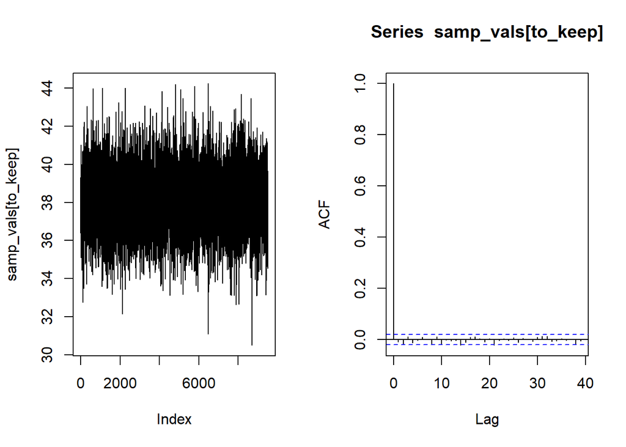

```r
# Priors for Treatment Group
mt <- 40
vt <- 100
at <- 1
bt <- 1

# Priors for Control Group
mc <- 35
vc <- 100
ac <- 1
bc <- 1

J <- 10000
out_t <- gibbs_normal_invGamma(m = mt, v = vt, a = at, b = bt, Y = tmt, J = J)
out_c <- gibbs_normal_invGamma(m = mc, v = vc, a = ac, b = bc, Y = control, J = J)

keep <- seq(500,J,by=1)
trace_acf(out_t$mu, to_keep = keep)
```

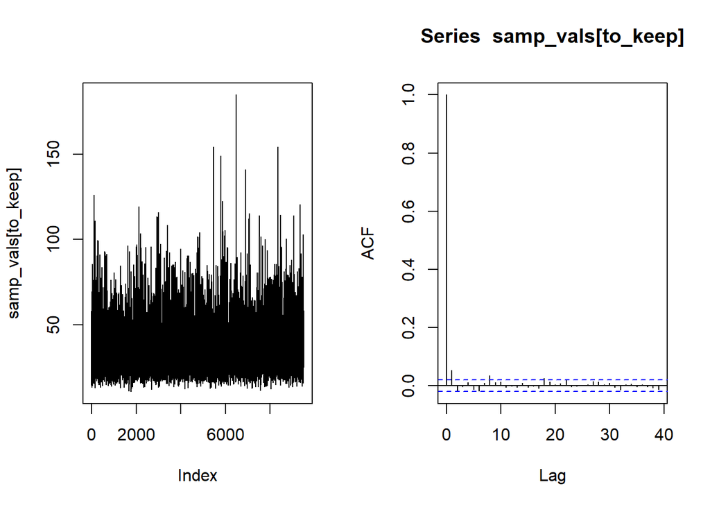

```r
trace_acf(out_t$sig2, to_keep = keep)
```

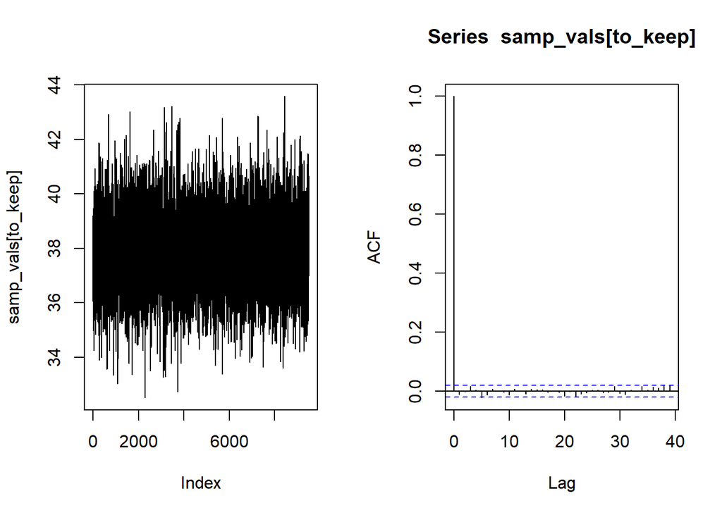

```r
trace_acf(out_c$mu, to_keep = keep)
```

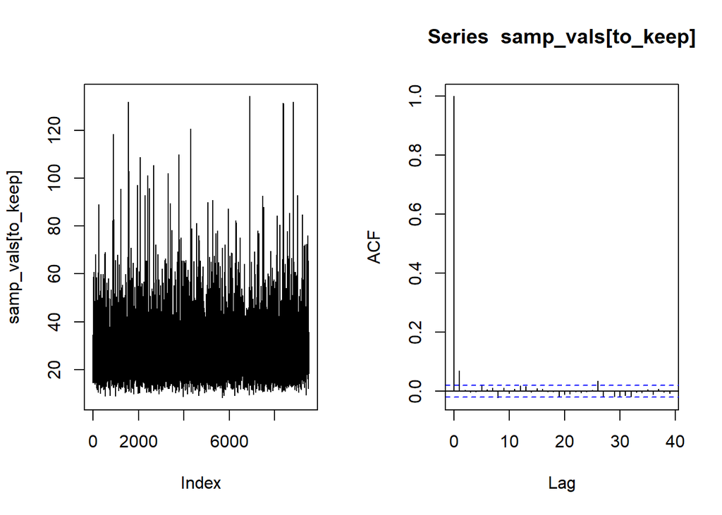

```r
trace_acf(out_c$sig2, to_keep = keep)
```

```r
out_t$mu <- out_t$mu[keep]
out_t$sig2 <- out_t$sig2[keep]
out_c$mu <- out_c$mu[keep]
out_c$sig2 <- out_c$sig2[keep]
```

2. Plot the posterior and prior distribution for each parameter on the same graph (you should have four figures). Make sure to include a legend to distinguish the prior from the posterior.

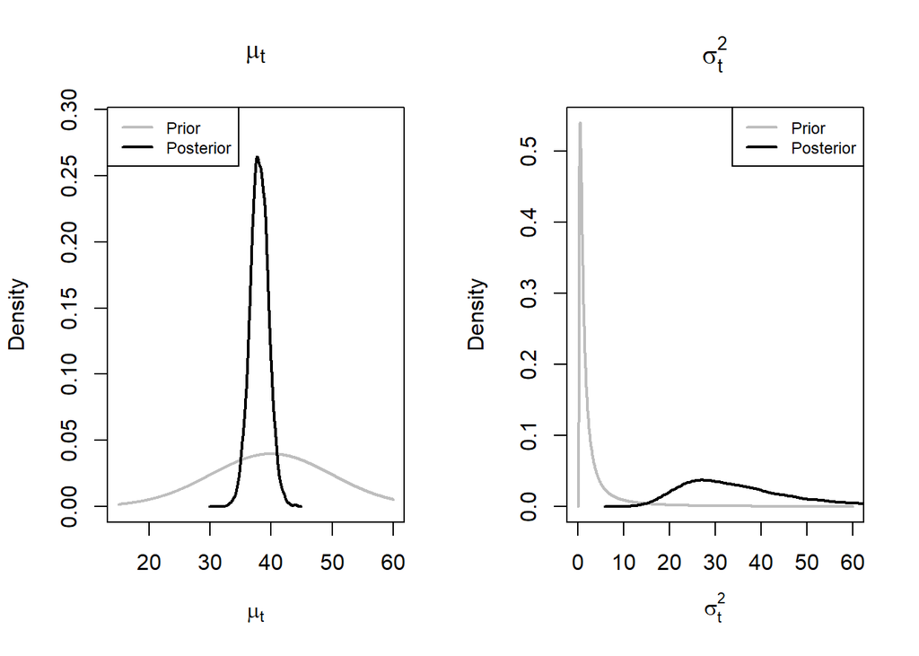

```r
par(mfrow=c(1,2))
x <- seq(15,60,length.out=1001)
plot(x,dnorm(x, mean = mt, sd = sqrt(vt)), lwd=2, type='l', col='gray', ylim = c(0,0.29),
     main = expression(mu[t]),
     xlab = expression(mu[t]), ylab = 'Density')
lines(density(out_t$mu), col = 'black', lwd = 2)
legend('topleft',c('Prior', 'Posterior'), lwd=c(2,2), lty=c(1,1), col=c('gray','black'),cex=0.75)

x <- seq(0,60,length.out=1001)
plot(x,dinvgamma(x,shape=at,rate=bt),col='gray',type='l', lwd=2,
     main = expression(sigma[t]^2),
     xlab = expression(sigma[t]^2), ylab = 'Density')
lines(density(out_t$sig2),lwd=2)
legend('topright',c('Prior', 'Posterior'), lwd=c(2,2), lty=c(1,1), col=c('gray','black'),cex=0.75)
```

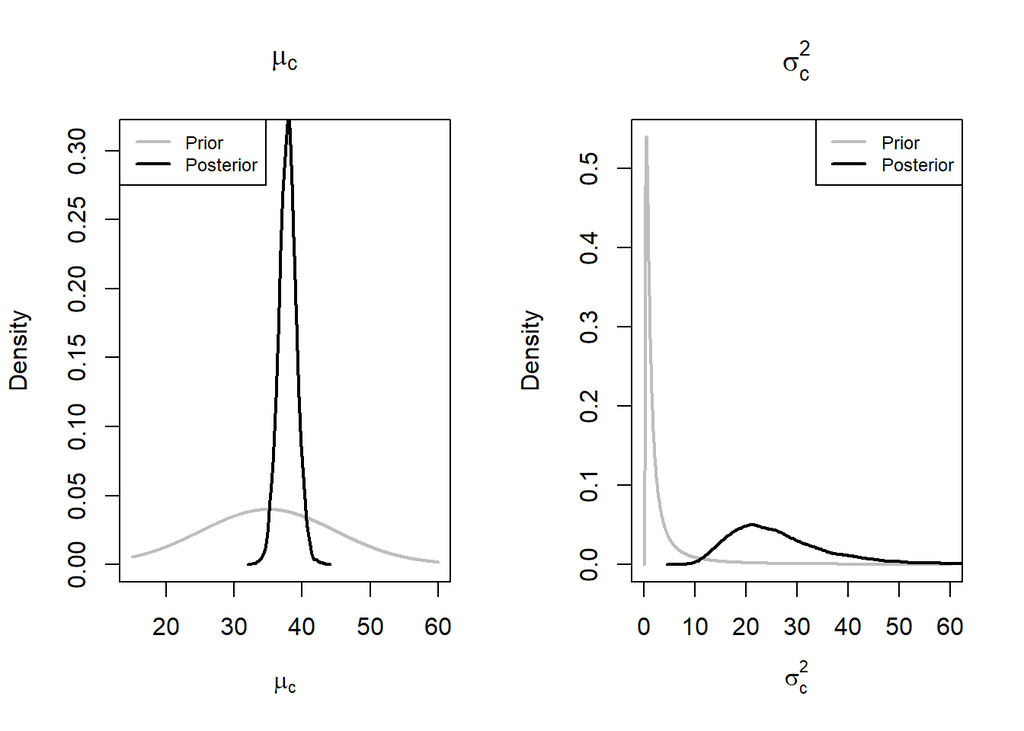

```r
par(mfrow=c(1,2))
x <- seq(15,60,length.out=1001)
plot(x,dnorm(x, mean = mc, sd = sqrt(vc)), lwd=2, type='l', col='gray', ylim = c(0,0.31),
     main = expression(mu[c]),
     xlab = expression(mu[c]), ylab = 'Density')
lines(density(out_c$mu), col = 'black', lwd = 2)
legend('topleft',c('Prior', 'Posterior'), lty=c(1,1), lwd=c(2,2), col=c('gray','black'),cex=0.75)

x <- seq(0,60,length.out=1001)
plot(x,dinvgamma(x,shape=ac,rate=bc),col='gray',type='l', lwd=2,
     main = expression(sigma[c]^2),
     xlab = expression(sigma[c]^2), ylab = 'Density')
lines(density(out_c$sig2),lwd=2)
legend('topright',c('Prior', 'Posterior'), lwd=c(2,2), lty=c(1,1), col=c('gray','black'),cex=0.75)
```

3. Using the draws from the posterior distribution, test the hypothesis provided above. Clearly indicate what conclusions you make in the context of the problem

```r
diffs <- out_c$mu - out_t$mu
mean(diffs)
```

```
## [1] -0.1852029
```

```r
quantile(diffs,c(0.025,0.975))
```

```
##      2.5%     97.5%
## -4.141386  3.766407
```

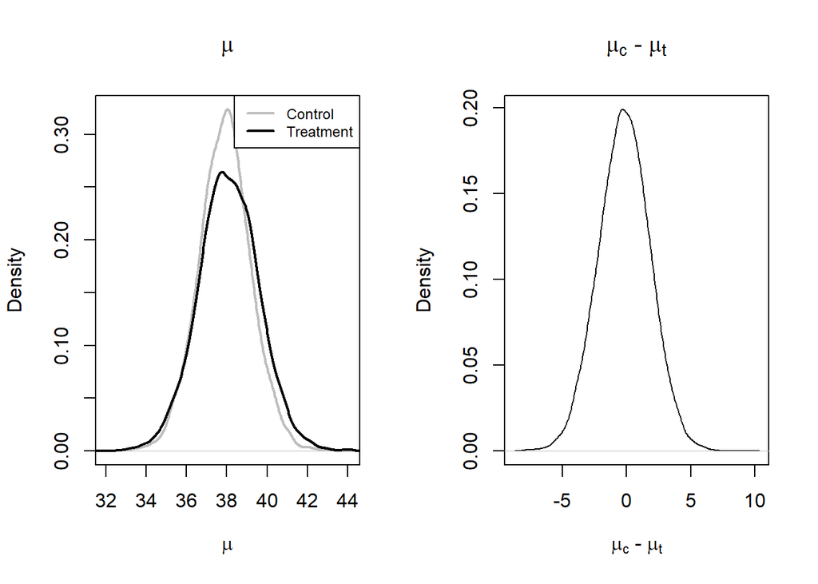

```r
par(mfrow=c(1,2))
plot(density(out_c$mu),col='gray',lwd=2,
     main = expression(mu),
     xlab = expression(mu),ylab='Density')
lines(density(out_t$mu),col='black',lwd=2)
legend('topright', c('Control','Treatment'), lty=c(1,1), lwd=c(2,2), col=c('gray','black'),cex=0.75)

plot(density(diffs),
     main=expression(paste(mu[c],' - ', mu[t])),
     xlab=expression(paste(mu[c],' - ', mu[t])),ylab='Density')
```

Here, we fail to reject the null hypothesis. There is a 95% probability that the true difference of means is between -4.14 and 3.77. This interval includes 0, so there does not appear to be a statistically significant difference between the two groups.

4. A separate researcher decided that since the two cows in the same pair share identical genetic background, their responses will be more similar than two cows that were from different pairs. There is a natural pairing. As the samples drawn from the two populations cannot be considered independent of each other, they decided to take differences $d_i = y_{ic} - y_{it})$. The differences will be assumed conditionally iid $\mathcal{N}(\mu_d,\sigma_d^2)$ where $\mu_d = \mu_c - \mu_t$ and we will assume that $\sigma_d^2 = 7$ is known. The researcher believes that the mean of the differences in yeild between the treatment and control groups is fairly close to zero and is quite certain (say 95%) that the difference is not more than ±15.
1. Formulate a prior distribution for $\mu_d$ according to the information provided by the researcher.

```r
cow_pairs <- control - tmt
cow_sig2 <- 7
# Priors
mp <- mc - mt
vp <- vc + vt
```

2. Is the assumption of normality for differences in yield sensible?

I think this assumption is sensible, since the sum (or difference) of 2 normal distributions is a normal distribution.

3. Identify the posterior distribution of $\mu_d$ (i.e., $\pi(\mu_d|\sigma_d^2, d_1, . . . ,d_n))$ and use it to test the hypothesis that $H_0:\mu_d \ge 0$ vs $H_a:\mu_d < 0$

```r
n <- length(cow_pairs)
y_bar <- mean(cow_pairs)

# update m
mp_star <- ((n*vp*y_bar) + (cow_sig2*mp)) / (n*vp + cow_sig2)
# update v
vp_star <- (vp*cow_sig2) / (n*vp + cow_sig2)
```

$\pi(\mu_d|\sigma_d^2, d_1, . . . ,d_n)) \sim \mathcal{N}(m^*=$ -0.08 $,v^*=$ 0.47 $)$.

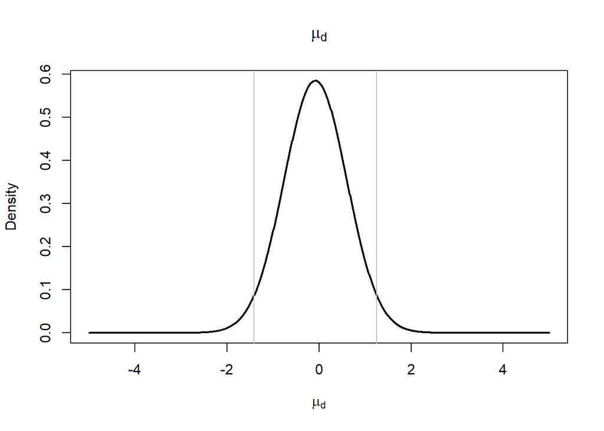

```r
interval <- qnorm(c(0.025,0.975),mean=mp_star,sd=sqrt(vp_star))
x <- seq(-5,5,length.out=1001)
plot(x,dnorm(x,mean=mp_star,sd=sqrt(vp_star)), type='l',lwd=2,
     main=expression(mu[d]),
     xlab=expression(mu[d]),ylab='Density')
abline(v=interval,col='gray')
```

5. Which of the two analysis is more appropriate in this scenario? Why? In your answer to this problem focus on how the analysis was carried out, not the fact that in one scenario the population variance is assumed known and in the other it is not.

To me, the second approach makes more sense because the researcher would have a better idea than I do about the relationship between cows. If they think that the twins should be paired than he is probably right, especially since they went to all the trouble of finding identical twins to experiment on. That being said, assuming the difference is not more than ±15 is not much of an assumption at all, so maybe he does not know what he is talking about…

### Part 2

To answer the question well, you will need to convince me that the MCMC algorithms for both models have converged and mix well. Then you will need to report a summary of the posterior distribution of $\beta_{1h} − \beta_{1d}$ that provides concrete evidence in support of the answer you supply.

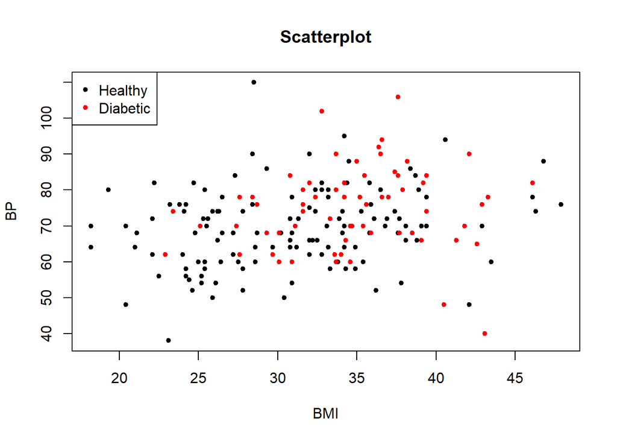

```r
Xh <- Pima.tr$bmi[Pima.tr$type == "No"]
Yh <- Pima.tr$bp[Pima.tr$type == "No"]
Xd <- Pima.tr$bmi[Pima.tr$type != "No"]
Yd <- Pima.tr$bp[Pima.tr$type != "No"]

m1 <- m0 <- 1
v1 <- v0 <- 100^2
a <- b <- 1

plot(Xh,Yh,pch=20,col='black',main="Scatterplot", xlab="BMI", ylab="BP")
points(Xd,Yd,pch=20, col='red')
legend('topleft',c("Healthy","Diabetic"),col=c('black','red'),pch=20)
```

```r
fit_lr <- function(X,Y, m0,m1, v0,v1, a,b, J = 10000) {
  beta0 <- numeric()
  beta1 <- numeric()
  sigma2 <- numeric()

  # starting values
  beta0[1] <- 0
  beta1[1] <- 0
  sigma2[1] <- 1

  n <- length(Y)
  y_bar <- mean(Y)
  y_var <- var(Y)

  for (j in 2:J) {

    # update sigma2
    a_star <- n/2 + a
    b_star <- .5*sum((Y - (beta0[j-1] + beta1[j-1]*X))**2) + b
    sigma2[j] <- rinvgamma(1,shape=a_star,rate=b_star)

    # update beta0
    v_star <- 1 / (n/sigma2[j] + 1/v0)
    m_star <- v_star * ((1/sigma2[j] * sum(Y - beta1[j-1]*X) + m0/v0))
    beta0[j] <- rnorm(1,mean=m_star,sd=sqrt(v_star))

    # Update beta1
    v_star <- 1/(sum(X**2)/sigma2[j] + 1/v1)
    m_star <- v_star *((1/sigma2[j])*sum(X*(Y - beta0[j])) + m1/v1)
    beta1[j] <- rnorm(1, mean = m_star, sd = sqrt(v_star))
  }
  out <- NULL
  out$beta0 <- beta0
  out$beta1 <- beta1
  out$sigma2 <- sigma2
  return(out)
}
```

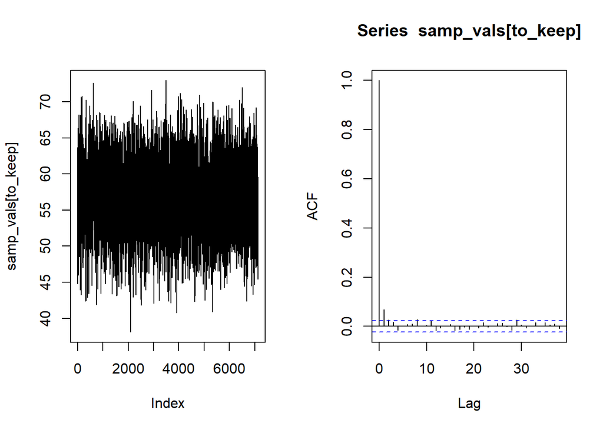

```r
J <- 500000
out_h <- fit_lr(Xh,Yh, m0,m1, v0,v1, a,b, J)
keep <- seq(from=1000, to=J,by=70)

trace_acf(out_h$beta0, keep)
```

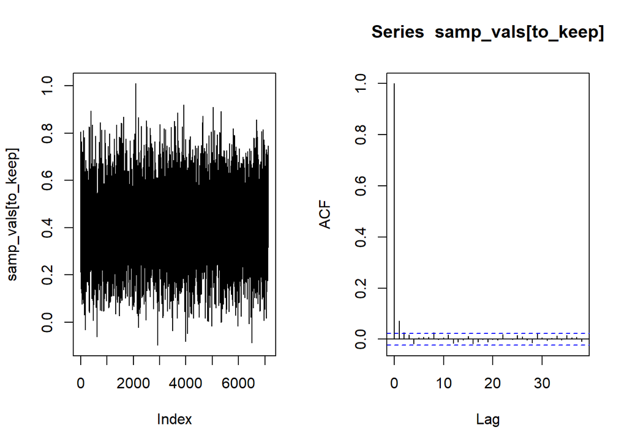

```r
trace_acf(out_h$beta1, keep)
```

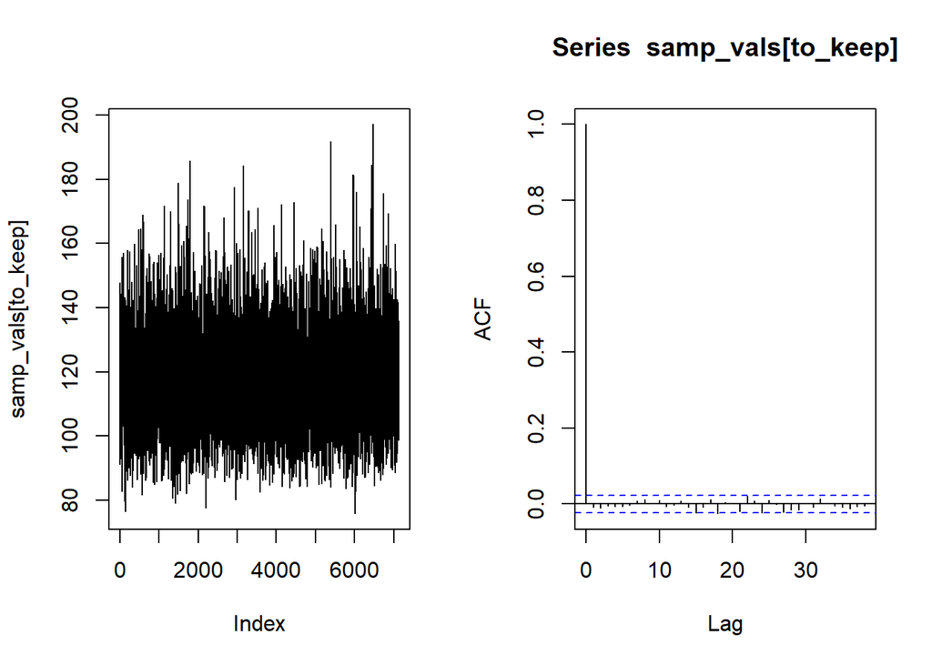

```r
trace_acf(out_h$sigma2, keep)
```

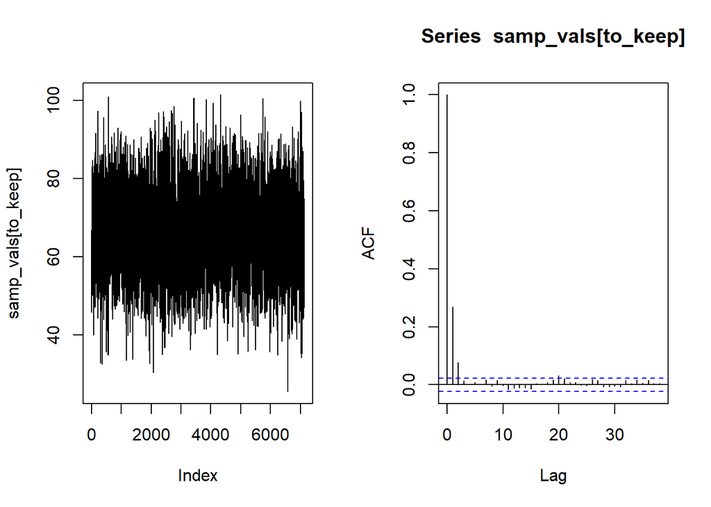

```r
J <- 500000
out_d <- fit_lr(Xd,Yd, m0,m1, v0,v1, a,b, J)
keep <- seq(from=1000, to=J,by=70)
trace_acf(out_d$beta0, keep)
```

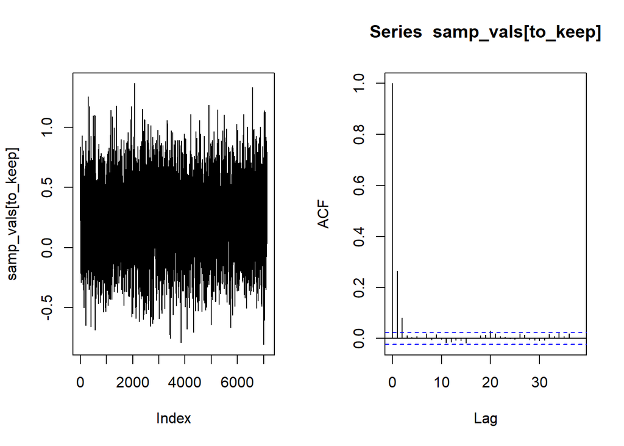

```r
trace_acf(out_d$beta1, keep)
```

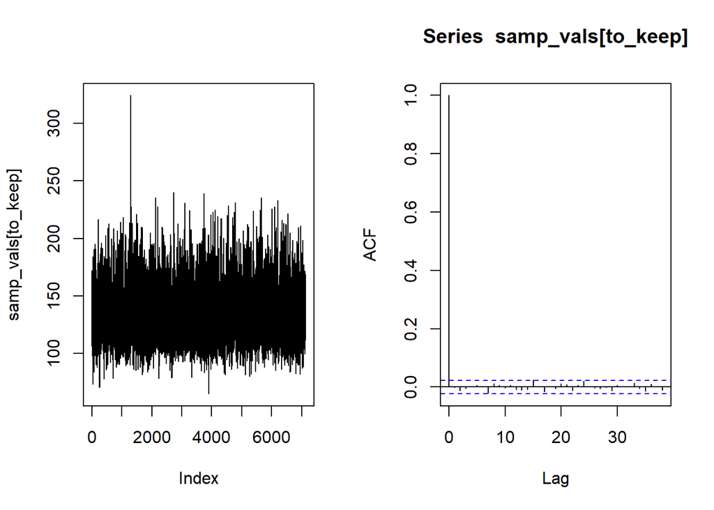

```r
trace_acf(out_d$sigma2, keep)
```

The MCMC algorithms seem to have converged for both models. Now comparing $\beta_{1h} - \beta_{1d}$.

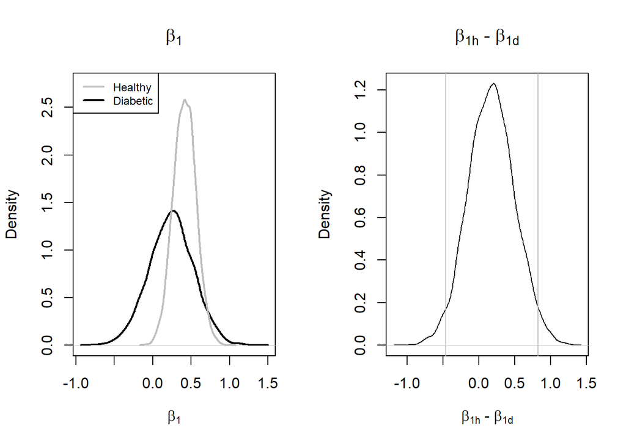

```r
par(mfrow=c(1,2))
plot(density(out_d$beta1[keep]),col='black',lwd=2,ylim=c(0,2.75),
     main = expression(beta[1]),
     xlab = expression(beta[1]),ylab='Density')
lines(density(out_h$beta1[keep]),col='gray',lwd=2)
legend('topleft', c('Healthy','Diabetic'), lty=c(1,1), lwd=c(2,2),
       col=c('gray','black'),cex=0.75)
diff_B1 <- out_h$beta1[keep] - out_d$beta1[keep]
interval_B1 <- quantile(diff_B1, c(0.025,0.975))
plot(density(diff_B1), main = expression(paste(beta['1h'], ' - ', beta['1d'])),
     xlab = expression(paste(beta['1h'], ' - ', beta['1d'])), ylab='Density')
abline(v=interval_B1,col='gray')
```

There is a 95% probability that the true difference of means is between -0.46 and 0.82. This interval includes 0, so there does not appear to be a statistically significant difference between the the slope for healthy and diabetic individuals.